# Révisions

Mahendra Mariadassou  
31 Octobre 2016

### Plan du cours (S1)

- Révisions générales
  - Ensembles de nombres
  - Manipulations standards
  - Fonctions usuelles
  - Trigonométrie
- Limite, Continuité et Dérivabilité
- Développements Limités

### Objectifs

- Connaître quelques propriétés de \( \mathbb{N} \), \( \mathbb{Q} \) et \( \mathbb{R} \)
- Savoir faire une récurrence
- Savoir manipuler des puissances (en particulier avec \( e^x \) et \( \ln{x} \))
- Savoir résoudre des équations et des inéquations
- Connaître les valeurs et les identités remarquables en trigonométrie

### Logique (vue avec Jérôme)

- Quantificateurs
- Tables de vérités
- Implications et équivalence
- Négation

### Mise en jambes

- Quelle est la négation de “Elena et Julie sont absentes.”?
- On considère la proposition \( (P) \) suivante \[ \forall \varepsilon > 0, \exists \delta > 0 \text{ tel que } \forall x \in ]a-\delta, a+\delta[, |f(x) - f(a)| \leq \varepsilon \]
  - de qui parle \( (P) \)?
  - comment est-elle modifiée si on inverse les deux premiers quantificateurs (\( \forall \) et \( \exists \))?
  - quelle est sa négation?
  - que signifie t-elle?

### Les nombres

On rappelle l'existence de d'ensembles de nombres déjà vu dans les classes antérieures:

- \( \mathbb{N} \): les entiers naturels (entiers positifs)
- \( \mathbb{Z} \): les entiers relatifs (entiers positifs et leurs opposés)
- \( \mathbb{Q} \): les rationnels (fractions d'entiers)
- \( \mathbb{R} \): les nombres réels (tous ceux qui peuvent apparaître comme la *mesure* de quelques chose et leurs opposés). La majorité des nombres réels ne sont pas rationnels: \( \sqrt{2}, \pi, e \).
- \( \mathbb{C} \): les nombres complexes (très utiles pour factoriser des polynômes ou représenter des courants électromagnétiques)

### Le principe de récurrence (classique)

Soit \( P(n) \) une propriété dépendant d'un entier \( n \). Soit \( n_0 \in \mathbb{N} \). Si les deux propriétés suivantes sont vérifiées:

- \( P(n_0) \) est vraie. [Initialisation]
- \( \forall n \geq n_0, P(n) \rightarrow P(n+1) \) [Hérédité]

Alors \( \forall n \geq n_0, P(n) \) est vraie

Soit \( n \) un entier naturel non nul, trouver une formule close et la démontrer (c'est à dire sans \( \dots \)) pour \( S_n = \frac{1}{2!} + \frac{2}{3!} + \dots + \frac{n-1}{n!} + \frac{n}{(n+1)!} \)

### La factorielle

La factorielle d'un entier naturel \( n \), noté \( n! \), est le produit des nombres entiers strictement positifs inférieurs ou égaux à \( n \). En d'autre termes, \( n! = 1 \times 2 \times \dots \times (n-1) \times n \)  
Par convention, \( 0! = 1 \).

**Remarque** On note que \( n! = n \times (n-1)! \).

On donne ici les valeurs de \( n! \) pour de faibles valeurs de \( n \)

| n | factorielle |
| --- | --- |
| 1 | 1 |
| 2 | 2 |
| 3 | 6 |
| 4 | 24 |
| 5 | 120 |

### Parité, imparité et division euclidienne

Tout nombre entier \( n \) est soit pair, soit impair.

- Si \( n \) est pair, il existe un **unique** entier \( p \) tel que \( n = 2p \)
- Si \( n \) est impair, il existe un **unique** entier \( p \) tel que \( n = 2p+1 \)

**Généralisation (division euclidienne)**

Pour tout entier naturel \( n \) et tout entier naturel non num \( d \), il existe un unique couple d'entiers \( (q, r) \) tel que: \[ n = dq + r \text{ et } 0 \leq r \leq d-1 \] \( n \) est **divisible** par \( d \) si et seulement si \( r = 0 \).

Montrer que le couple \( (q,r) \) existe (par récurrence) et qu'il est unique (par l'absurde)

### Nombres réels

- Justifier l'existence d'un nombre réel dont le carré est égal à 2. À quelle mesure correspond-il?
- Montrer (par l'absurde) que \( \sqrt{2} \) n'est pas rationnel. On pourra commencer par démontrer que \( p^2 \) est pair si et seulement si \( p \) est pair

**Remarque**

\( \sqrt{2}, \pi, e \) sont des nombres irrationnels. La nécessité de construire \( \mathbb{R} \) provient de raisons non-algébriques, pour manipuler des quantités d'intérêt (en géométrie pour \( \sqrt{2} \) et \( \pi \), en calculs d'intérêts pour \( e \)) qu'on ne peut pas exprimer comme des fractions d'entiers.

### Majorant, minorant

Un sous ensemble \( A \subset \mathbb{R} \) est dit majoré (resp. minoré) s'il existe un réel \( M \) (resp. \( m \)) tel que \[ \forall x \in A, x \leq M \quad \quad \text{(resp. } x \geq m \text{)} \] On dit alors que \( M \) est majorant (resp. \( m \) est un minorant) de \( A \).  
Si \( A \) est à la fois majorée et minorée, elle est bornée.

- Écrire avec des quantificateurs:
- \( A \) n'est pas majorée (ou minorée)
- \( A \) n'est pas bornée
- Montrer que \( A \) est bornée si et seulement si il existe un réel \( M \) tel que \( \forall x \in A, |x| \leq M \)

### Borne supérieure, inférieure

Si \( M \) est un majorant de \( A \), alors \( M+1, M+2, \dots \), aussi. On peut chercher le *plus petit* majorant.

Soit \( A \) une partie non-vide de \( \mathbb{R} \), alors on dit que:

- \( A \) admet une borne supérieure lorsqu'il existe un réel \( M_0 \) tel que

\( M_0 \) est un majorant de \( A \)

- Tout majorant \( M \) de \( A \) vérifie \( M \geq M_0 \)
- \( A \) admet une borne inférieure lorsqu'il existe un réel \( m_0 \) tel que
- \( m_0 \) est un minorant de \( A \)
- Tout minorant \( m \) de \( A \) vérifie \( m \leq m_0 \)

Si \( A \) admet une borne supérieure (resp. inférieure), alors elle est unique. On la note \( \sup A \) (resp. \( \inf A \)) ou encore \( \sup_{x \in A} x \) (resp. \( \inf_{x \in A} x \))

### Borne supérieure, inférieure [admis]

Soit \( A \) une partie non-vide de \( \mathbb{R} \).

- Si \( A \) est majorée, elle admet une borne supérieure.
- Si \( A \) est minorée, elle admet une borne inférieure.
- La borne supérieure \( \sup A \) est-elle systématiquement un élément de \( A \)?
- Même question pour \( \inf A \)?

### Maximum, Minimum

- Soit \( A \) une partie majorée de \( \mathbb{R} \). Si \( \sup A \) est un élément de \( A \), on dit que \( \sup A \) est le maximum de \( A \), noté \( \max A \).
- Soit \( A \) une partie minorée de \( \mathbb{R} \). Si \( \inf A \) est un élément de \( A \), on dit que \( \inf A \) est le minimum de \( A \), noté \( \min A \).

**Questions**

- Quelles parties de \( \mathbb{R} \) admettent un maximum? un minimum?

**Réponses partielles**

- Toute partie **finie** de \( \mathbb{R} \) admet un maximum et un minimum
- Toute partie *majorée* (resp. *minorée*) de \( \mathbb{Z} \) admet un maximum (resp. un minimum). Mais ce n'est plus vrai avec \( \mathbb{Q} \).

### Intervalle

Un intervalle est un sous-ensemble \( I \) de \( \mathbb{R} \) tel que si \( x \) et \( y \) sont dans \( I \) alors tout \( t \) compris entre \( x \) et \( y \) est élément de \( I \).

**Remarque** Un intervalle est un sous-ensemble de \( \mathbb{R} \) sans “trous”, sans discontinuité.

Il y a 3 types d'intervalles:

- *ouvert*: \( ]a, b[ = \{ x \in \mathbb{R} \quad \text{tels que} \quad a < x < b \} \) avec \( a \) et \( b \) dans \( \mathbb{R} \cup \{-\infty, +\infty\} \)
- *semi-ouvert*: \( [a, b[ = \{ x \in \mathbb{R} \quad \text{tels que} \quad a \leq x < b \} \) avec \( a \in \mathbb{R} \) et \( b \in \mathbb{R} \cup \{+\infty\} \) ou \( ]a, b] \) avec des contraintes sumilaires.
- *fermés*: \( [a, b] = \{ x \in \mathbb{R} \quad \text{tels que} \quad a \leq x \leq b \} \) avec \( a \) et \( b \) dans \( \mathbb{R} \)

Un intervalle est dit **non-trivial** lorsqu'il est non vide et non réduit à un point.

### Manipulations standards

**À connaitre**

- Développer / Factoriser
- Identités remarquables
- Manipulation de puissances (\( e^x \) et \( \ln \))
- Trigonométrie

**Interdit**

- Diviser par \( 0 \)
- Racine d'un nombre négatif
- logarithme d'un nombre négatif ou nul

### Fonctions valeur absolue et partie entière

**Valeur absolue**

Soit \( x \in \mathbb{R} \), la valeur absolue de \( x \), notée \( |x| \) est définie par \[ |x| = \max(x, -x) \]

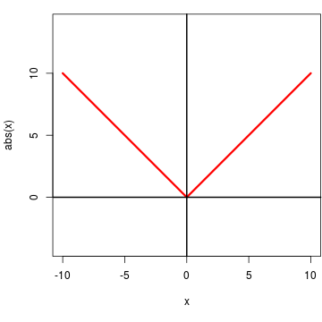

**Partie Entière**

Soit \( x \in \mathbb{R} \), la partie entière de \( x \), notée \( \lfloor x \rfloor \) est définie par \[ \lfloor x \rfloor \in \mathbb{Z} \quad \text{et} \quad \lfloor x \rfloor \leq x < \lfloor x \rfloor + 1 \]

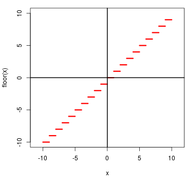

### Fonctions valeur absolue et partie entière (II)

Simplifier les expressions suivantes:

- \( \lfloor \pi \rfloor \),
- \( \lfloor 0.99 \rfloor \), \( \lfloor 1 \rfloor \), \( \lfloor 1.01 \rfloor \)
- \( \lfloor -0.99 \rfloor \), \( \lfloor -1 \rfloor \), \( \lfloor -1.01 \rfloor \)

Résoudre les équations d'inconnue \( x \) suivantes:

- \( \lfloor 2x + 1 \rfloor= 3 \).
- \( |2x + 1| = 3 \)

### Puissance

Pour \( a > 0 \) et \( x \in \mathbb{R} \), on pose \( a^x = e^{x \ln a} \)

Si \( x, y \) sont deux rééls et \( a, b \) deux réels **strictement positifs**, on a:

| \( a^0 = 1 \) | \( a^{x+y} = a^x . a^y \) | \( (a)^{-x} = \frac{1}{a^x} \) |
| --- | --- | --- |
| \( a^{x -y} = \frac{a^x}{a^y} \) | \( (ab)^{x} = (a)^x . (b)^x \) | \( (a^x)^y = a^{x.y} \) |
| \( a^1 = a \) | \( (a^x)^{\frac{1}{x}} = a \) | \( \sqrt[n]{a} = a^{\frac{1}{n}} \) |

### Puissance (II)

**Rapppels**

- Si \( a > 0 \), \( \sqrt[n]{a} \) est l'unique réel **positif** tel que \( (\sqrt[n]{a})^n = a \).
- Pour tout réel \( x \), \( \sqrt{x^2} = |x| \) (et non pas \( x \)). La racine carrée est positive.

### Équations

Il y a deux grandes types d'équations:

- les polynômiales
- les autres

Pour les polynömiales, il faut savoir résoudre des équations de degré \( 1 \) et \( 2 \) et factoriser à partir de *racines évidentes* pour les celles de degrés supérieures. Pour les autres, il faut utiliser des astuces ad-hoc (mais avec quelques astuces classiques dont le changement de variables).

En présence de paramètres, il faut parfois faire des **disjonctions de cas** pour éviter de faire des opérations interdites.

### Équations à paramètres

Résoudre, en fonction des paramètres \( a \) et \( b \), les équations suivantes:

- \( ax = b \)
- \( ax +b = bx +a \)
- \( e^x = a \)
- \( ax^2 - 2bx + 2 = 0 \)

### Équations polynômiales

Résoudre les équations (de \( X \)) suivantes:

- \( X^3 - X^2 + X - 1 = 0 \)
- \( X^4 + X^2 - 1 = 0 \).

### Équations non-polynômiales

Résoudre les équations (de \( x \)) suivantes:

- \( 3x^4 + 5x^2 - 2 = 0 \)
- \( (\ln x)^2 + 3\ln x + 2 = 0 \)
- \( x = \sqrt{x} + 2 \)
- \( e^x - e^{-x} = 2 \)
- \( x^2 - 3x + 4 + \frac{8 - 6x}{x^2 - 2} = 0 \)

### Inégalités

Soient \( a \) et \( b \) deux réels tels que \( a \leq 5 \) et \( b \leq 6 \). Que peut-on dire de \( 2a \), \( -3b \), \( a+b \), \( a - b \), \( ab \), \( a/b \)? Même chose si \( b \geq 6 \).

### Inégalités: Règles de manipulation

- \( a \geq b \) équivaut à \( -a \leq -b \) [changement de signe]
- Si \( a \) et \( b \) ont même signe, \( a \leq b \) équivaut à \( \frac{1}{a} \geq \frac{1}{b} \)
- On peut additionner des égalités de même sens: si \( a \leq b \) et \( c \leq d \) alors \( a+c \leq b+d \).
- Si \( a, b, c, d \) sont positifs, on peut multiplier des inégalités: si \( a \leq b \) et \( c \leq d \) alors \( ac \leq bd \)
- Si \( f \) est une fonction croissante sur un **intervalle** \( I \subset \mathbb{R} \) et \( a \) et \( b \) sont des éléments de \( I \) tels que \( a \leq b \), alors \( f(a) \leq f(b) \).
- Si \( f \) est une fonction décroissante sur un **intervalle** \( I \subset \mathbb{R} \) et \( a \) et \( b \) sont des éléments de \( I \) tels que \( a \leq b \), alors \( f(a) \geq f(b) \).

### Inégalité triangulaire et arithmético-géométrique

Pour tous réels \( x \) et \( y \), \( |x + y| \leq |x| + |y| \).

Cette égalité vient de la géométrie: dans un triangle, la sommes des longueurs de deux côtés est toujours supérieure ou égale à celle du troisième (avec égalité si et seulement si le triangle est aplati).

Montrer que pour tous réels \( x \) et \( y \), \( | |x| - |y| | \leq |x - y| \).

Montrer que pour tous réels \( x \) et \( y \), \( x^2 + y^2 \geq 2|xy| \). [inégalité arithmético-géométrique, à connaître]

### Inégalités: Mise en oeuvre

Résoudre les inégalités suivantes:

- \( \ln(3x) \leq \ln(2x) \)
- \( 3.2^{3x-4} \geq 7^8 \)
- \( 5\left( \frac{1}{3} \right)^{x} \leq 10^{-10} \)
- \( \sqrt{x} \geq x + 1 \)

### Trigonométrie: les bases (I)

La mesure en *radians* d'un angle \( \alpha \) est la longueur d'un arc de cercle de rayon \( 1 \) délimité par cet angle.

Plus généralement, soit \( \mathcal{C} \) est un cercle de centre \( O \) et de rayon \( R \). On considère deux points \( A \) et \( B \) de \( \mathcal{C} \). La *mesure principale* de l'angle \( \hat{AOB} \) est l'unique réel \( \alpha \) tel que

- \( \alpha \in [0, 2\pi [ \)
- la longeur de l'arc de cercle délimité par le secteur angulaire \( \hat{AOB} \) est \( R\alpha \), et son aire est \( \frac{\alpha}{2}R^2 \)

### Trigonométrie: les bases (II)

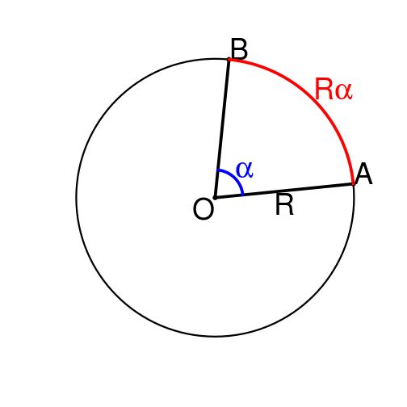

### Trigonométrie: angle orienté

Du point de vue des longueurs (positives par définition), on a le choix de “tourner” dans un sens ou dans l'autre. Dans de nombreux cas, la question du “sens” de rotation est néanmoins importante.  
Par définition, on décide que le sens positif est le sens contraire à celui des aiguilles d'une montre. C'est le sens trigonométrique.

Pour faire la différence avec les angles non-orientés, on utilise la notion d'**angle de vecteurs**.

Soient \( A, B, C \) 3 points du plan, l'angle orienté \( \hat{ABC} \) est noté \( (\vec{BA}, \vec{BC}) \).  
Plus généralement, pour tous vecteurs \( \vec{u} \), \( \vec{v} \) du plan, on note \( (\vec{u}, \vec{v}) \) l'angle orienté \( (\vec{BA}, \vec{BC}) \) pour tous points \( A, B, C \) tels que \( \vec{u} = \vec{BA} \) et \( \vec{v} = \vec{BC} \)

### Rotation de centre Ω et d'angle α

Soit \( \mathcal{P} \) le plan usuel orienté. Soit \( \Omega \) un point du plan et \( \alpha \) un réel. On appelle rotation de centre \( \Omega \) et d'angle \( \alpha \) l'application \( r : \mathcal{P} \rightarrow \mathcal{P} \) qui à tout point \( M \in \mathcal{P} \) associe le point \( M' = r(M) \) qui vérifie:

- \( |\Omega M| = |\Omega M'| \)
- \( (\vec{\Omega M}, \vec{\Omega M'}) = \alpha \)

### Définition géométrique des fonctions trigonométriques

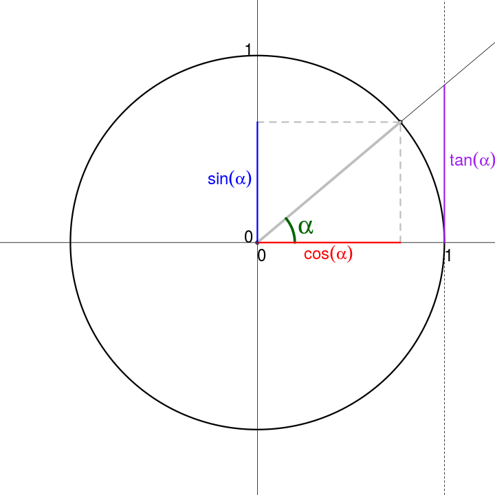

### Propriété fondamentale de sinus et cosinus

- Soit \( \theta \in \mathbb{R} \), on a \( \cos^2 \theta + \sin^2 \theta = 1 \)
- Réciproquement, pour tout couple \( (\alpha, \beta) \) de nombres réels tels que \( \alpha^2 + \beta^2 = 1 \), il existe un réel \( \theta \) tel que \( \alpha = \cos(\theta) \) et \( \beta = \sin(\theta) \).

Les deux propriétés traduisent le fait que le point \( M \) de coordonnées \( (\alpha, \beta) \) est sur le cercle trignométrique (celui de centre \( O = (0, 0) \) et de rayon \( 1 \)).

### Valeurs remarquables (à connaître...)

- Pour tout \( k \in \mathbb{Z} \), \( \cos(k\pi) = (-1)^k \), \( \sin(k\pi) = \tan(k\pi) = 0 \)
- Pour tout \( k \in \mathbb{Z} \), \( \cos(\pi/2 + k\pi) = 0 \), \( \sin(\pi/2 + k\pi) = (-1)^k \) et \( \tan(\pi/2 + k\pi) \) n'est pas défini.
- \( \cos(\pi/3) = \sin(\pi/6) = \frac{1}{2} \)
- \( \cos(\pi/6) = \sin(\pi/3) = \frac{\sqrt{3}}{2} \)
- \( \cos(\pi/4) = \sin(\pi/4) = \frac{\sqrt{2}}{2} \)
- \( \tan(\pi/3) = \frac{1}{\tan(\pi/6)} = \sqrt{3} \)
- \( \tan(\pi/4) = 1 \).

### Parité, périodicité (à connaître...)

- \( \forall x \in \mathbb{R}, \forall k \in \mathbb{Z}, \cos(2k\pi + x) = \cos(x), \sin(2k\pi + x) = \sin(x) \)
- \( \forall x \in \mathbb{R}, \forall k \in \mathbb{Z}, \cos((2k+1)\pi + x) = -\cos(x), \sin((2k+1)\pi + x) = -\sin(x) \)
- \( \forall x \in \mathbb{R}, \cos(-x) = \cos(x), \sin(-x) = -\sin(x) \)
- \( \forall x \in \mathbb{R}, \cos(\pi-x) = -\cos(x), \sin(\pi-x) = \sin(x) \)
- \( \forall x \in \mathbb{R}, \cos(\pi/2-x) = \sin(x), \sin(\pi/2-x) = \cos(x) \)
- \( \forall x \in \mathbb{R}, \cos(\pi/2+x) = -\sin(x), \sin(\pi/2+x) = \cos(x) \)

### Parité, périodicité (à connaître...)

- Pour tout réel \( x \in \mathbb{R} - \left\{\frac{\pi}{2} + k\pi, k \in \mathbb{Z} \right\} \), on a \( \tan{x} = \frac{\sin(x)}{\cos(x)} \)
- \( \forall x \in \mathbb{R} - \left\{\frac{\pi}{2} + k\pi, k \in \mathbb{Z} \right\}, \forall k \in \mathbb{Z} \), on a \( \tan(x + k\pi) = \frac{\sin(x)}{\cos(x)} \)
- \( \forall x \in \mathbb{R} - \left\{\frac{\pi}{2} + k\pi, k \in \mathbb{Z} \right\}, \forall k \in \mathbb{Z} \), on a \( \tan(-x) = -\tan(x) \)
- \( \forall x \in \mathbb{R} - \left\{\frac{\pi}{2} + k\pi, k \in \mathbb{Z} \right\}, \forall k \in \mathbb{Z} \), on a \( \tan(\pi/2-x) = \frac{1}{\tan(x)} \)
- \( \forall x \in \mathbb{R} - \left\{\frac{\pi}{2} + k\pi, k \in \mathbb{Z} \right\}, \forall k \in \mathbb{Z} \), on a \( \tan(\pi/2+x) = -\frac{1}{\tan(x)} \)

### Formules d'additions

Seules les deux premières sont nécessaires, les autres s'en déduisent.

Pour tout couple de réels \( (a, b) \), on a:

- \( \cos(a+b) = \cos(a)\cos(b) - \sin(a)\sin(b) \)
- \( \sin(a+b) = \sin(a)\cos(b) + \cos(a)\sin(b) \)
- \( \cos(a-b) = \cos(a)\cos(b) + \sin(a)\sin(b) \)
- \( \sin(a-b) = \sin(a)\cos(b) - \cos(a)\sin(b) \) Et sous réserve que les tangentes soient bien définies
- \( \tan(a+b) = \frac{\tan(a) + \tan(b)}{1 - \tan(a)\tan(b)} \)
- \( \tan(a-b) = \frac{\tan(a) - \tan(b)}{1 + \tan(a)\tan(b)} \)

### Formules de factorisation

Elles se démontrent à partir des formules d'addition (voir feuille d'exercice)

Pour tout couple de réels \( (a, b) \), on a:

- \( \cos(a) + \cos(b) = 2\cos\left(\frac{a+b}{2}\right)\cos\left(\frac{a-b}{2}\right) \)
- \( \sin(a) + \sin(b) = 2\sin\left(\frac{a+b}{2}\right)\cos\left(\frac{a-b}{2}\right) \)

En cas de doute, n'hésitez pas à tester ces formules sur des valeurs connues (par exemple \( a = b \) ou \( a = -b \)) pour vérifier que vous avez la bonne formule. .

### Angles doubles

Le cas \( a=b \) correspond à un cas particulier d'intérêt (appelé angle double). Les formules d'additions se simplifient alors en

- \( \cos(2a) = \cos^2(a) - \sin^2(a) = 2\cos^2(a) - 1 = 1 - 2\sin^2(a) \)
- \( \sin(2a) = 2\sin(a)\cos(a) \)
- \( \tan(2a) = \frac{2\tan(a)}{1 - \tan^2(a)} \)

### Équations trigonométriques fondamentales (I)

Soit \( u \) un réel donné, on cherche à résoudre les équations d'inconnue \( x \).

- \( \cos(u)=\cos(x) \)

\( x \) est solution si et seulement si \( \begin{cases} \exists k\in \mathbb{Z} \text{ tel que } x = u + 2k\pi \\ \text{OU} \\ \exists k\in \mathbb{Z} \text{ tel que } x = -u + 2k\pi\end{cases} \)

- \( \sin(u)=\sin(x) \)

\( x \) est solution si et seulement si \( \begin{cases} \exists k\in \mathbb{Z} \text{ tel que } x = u + 2k\pi \\ \text{OU} \\ \exists k\in \mathbb{Z} \text{ tel que } x = \pi-u + 2k\pi\end{cases} \)

Attention à ne pas oublier le **OU** du système.

### Équations trigonométriques fondamentales (II)

Soit \( u \) un réel donnéon cherche à résoudre les équations d'inconnue \( x \).

- \( \tan(u)=\tan(x) \) (où \( u \) n'est pas de la forme \( \pi/2 + k\pi \))

\( x \) est solution si et seulement si \( \exists k\in \mathbb{Z} \) tel que \( x = u + k\pi \)

- \( \sin(u)=\sin(x) \) ET \( \cos(u)=\cos(x) \)

\( x \) est solution si et seulement si \( \exists k\in \mathbb{Z} \) tel que \( x = u + 2k\pi \)

### Applications

Résoudre les équations suivantes:

- \( \cos(x) = \frac{1}{2} \)
- \( \sin(2x) = \frac{\sqrt{3}}{2} \)
- \( \tan(3x) = 1 \)

### Fonctions trigonométriques inverses (admises)

- Pour tout réel \( x \in [-1, 1] \), l'équation d'inconnue \( \theta \) \( \cos(\theta) = x \) admet une unique solution dans **\( [0, \pi] \)**. Cette solution est appelée \( \arccos(x) \).
- Pour tout réel \( x \in [-1, 1] \), l'équation d'inconnue \( \theta \) \( \sin(\theta) = x \) admet une unique solution dans **\( \left[-\frac{\pi}{2}, \frac{\pi}{2}\right] \)**. Cette solution est appelée \( \arcsin(x) \).
- Pour tout réel \( x \in \mathbb{R} \), l'équation d'inconnue \( \theta \) \( \tan(\theta) = x \) admet une unique solution dans **\( \left]-\frac{\pi}{2}, \frac{\pi}{2}\right[ \)**. Cette solution est appelée \( \arctan(x) \).

Attention à l'**intervalle** auquel appartient \( \theta \)!!

### Cos et Arccos

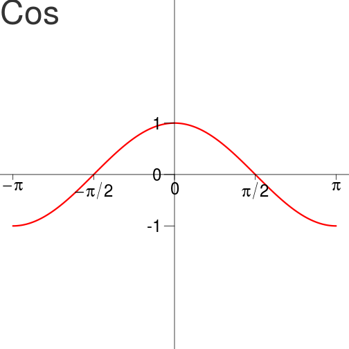

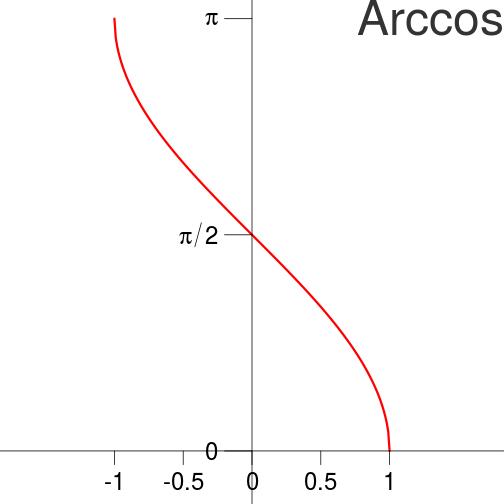

### Sin et Arsin

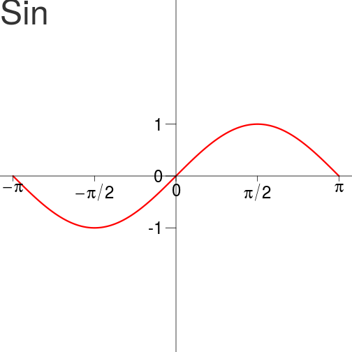

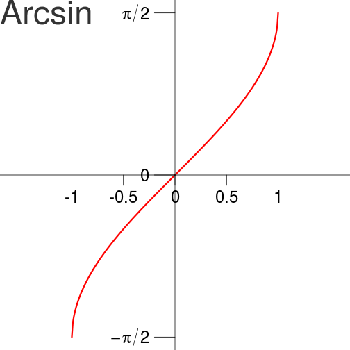

### Tan et Arctan

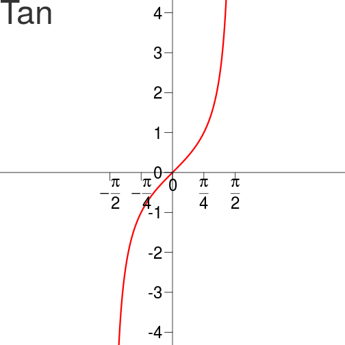

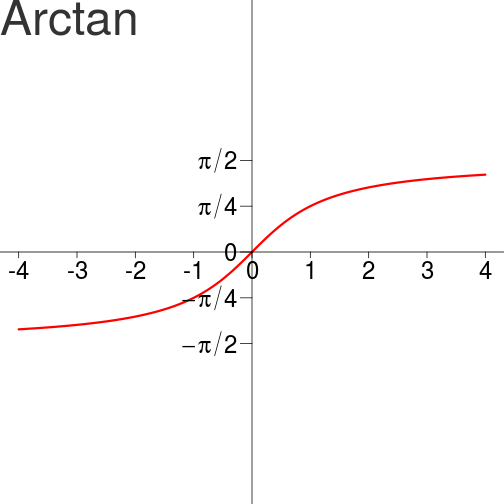

### Équations trigonométriques fondamentales (I)

- \( \cos(x)=a \)
  - Si \( a \notin [-1, 1] \): pas de solution
  - Si \( a \in [-1, 1] \): \( x \) est solution si et seulement si \( \begin{cases} \exists k\in \mathbb{Z} \text{ tel que } x = \arccos(a) + 2k\pi \text{ OU} \\ \exists k\in \mathbb{Z} \text{ tel que } x = -\arccos(a) + 2k\pi\end{cases} \)
- \( \sin(x)=a \)
  - Si \( a \notin [-1, 1] \): pas de solution
  - Si \( a \in [-1, 1] \): \( x \) est solution si et seulement si \( \begin{cases} \exists k\in \mathbb{Z} \text{ tel que } x = \arcsin(a) + 2k\pi \text{ OU} \\ \exists k\in \mathbb{Z} \text{ tel que } x = \pi -\arcsin(a) + 2k\pi\end{cases} \)

### Équations trigonométriques fondamentales (II)

- \( \tan(x)=a \)

\( x \) est solution si et seulement si \( \exists k\in \mathbb{Z} \) tel que \( x = \arctan(a) + k\pi \)

La deuxième formulation est plus générale que la première.

Attention, si on demande les solutions dans un intervalle donnée (par exemple \( [0, \pi] \)), il faut sélectionner uniquement les valeurs de \( k \) tel que \( x \) soit dans le bon intervalle. Par exemple, les solutions de \( \sin(x) = 1 \) dans \( [0, 4\pi] \) sont \( x = \frac{\pi}{2} \) et \( x = \frac{5\pi}{2} \)

### Factorisation

Soit \( (a, b) \in \mathbb{R}^2 \). Il existe \( (R, \psi, \phi) \in \mathbb{R}^2 \) tel que: \[ \forall x\in\mathbb{R}, \quad a\cos(x) + b\sin(x) = R\cos(x + \psi) = R\sin(x + \phi) \]

- Si \( a = b = 0 \), on peut prendre \( R = \psi = \phi = 0 \).
- Sinon, on pose \( R = \sqrt{a^2 + b^2} \). On a alors: \[ a\cos(x) + b\sin(x) = R \left( \frac{a}{R}\cos(x) + \frac{b}{R}\sin(x) \right) \] On remarque que \( (a/R)^2 + (b/R)^2 = 1 \), il existe donc \( \psi \) tel que \[ \cos(\psi) = a/R \text{ et } \sin(\psi) = b/R \] On conclut avec les formules d'addition.

### Applications

Résoudre les équations suivantes, dans \( \mathbb{R} \) puis dans \( [0, 2\pi] \):

- \( \sin(2x) = \frac{1}{2} \)
- \( \sin(nx) = 0 \)
- \( \sin(2x) + \sin(x) = 0 \)
- \( \cos(x) + \sin(x) = 1 \)
- \( \sqrt{3}\cos(2x) + \sin(2x) > 0 \)

### Notations Somme et Produit

On utilise les signes \( \sum \) et \( \prod \) pour désigner des sommes et des produits

\[ \sum_{i = 0}^n u_i = u_0 + u_1 + \dots + u_{n-1} + u_n \]

\[ \prod_{i = 0}^n u_i = u_0 \times u_1 \times \dots \times u_{n-1} \times u_n \]

L'ensemble des valeurs prises par l'indice \( î \) est ici \( \{0, 1, \dots, n-1, n\} \) mais il peut bien sûr être différent. Par exemple, on peut remarquer que pour tout \( n \geq 1 \), on a \( n! = \prod_{i=1}^n i \).

### Variable muette

La variable \( i \) dans la notation précédente est dite **muette**, elle n'a de sens qu'à l'intérieur de CE symbole \( \sum \) (ou \( \prod \)).

Autrement dit les \( î \) situés à l'**extérieur** du symbole \( \sum \) sont complétement sans indépendants des \( i \) situés à l'**intérieur** du symbole \( \sum \).

On peut donc remplacer le symbole \( i \) par un autre, par exemple \( j \), à condition de rester **cohérent**: \[ \sum_{i = 0}^n u_i = \sum_{j = 0}^n u_j \]

### Exemples

Calculer

- \( \sum_{i=1}^n 1 \)
- \( \sum_{i=1}^n i \quad \) (voir exercice de récurrence)
- \( \sum_{i=1}^n n \)
- \( \sum_{i=1}^n (-1)^i \)
- \( \sum_{i=1}^n (-1)^n \)

### Linéarité des sommes

Soit \( n \) un entier, \( (a_i)_i \) et \( (b_i)_i \) deux familles indexées par \( i \in \{1, \dots, n\} \) et \( \lambda \) un réel. On a \[ \sum_{i = 0}^n (a_i + b_i) = \sum_{i = 0}^n a_i + \sum_{i = 0}^n b_i \quad \text{et} \quad \sum_{i = 0}^n (\lambda \times a_i) = \lambda \times \sum_{i = 0}^n a_i \]

### Décalage d'indices

Conseil: Posez clairement le *changement de variable* et faites le en 3 étapes

- **Variable** Posons \( j = i+1 \)
- **Bornes** Lorsque \( i \) vaut \( 1 \), \( j \) vaut \( 2 \) et lorsque \( i \) vaut \( n \), \( j \) vaut \( n+1 \).
- **Corps de la somme** Remplaçons tous les \( i \) par des \( j-1 \)

### Exemple

Montrer que pour tout \( n \in \mathbb{N} \), on a \[ \sum_{k=1}^n k^2 = n + 2\sum_{k=1}^{n-1}k + \sum_{k=0}^{n-1} k^2 \]

### Résultats classique (à connaître)

On peut démontrer tous ces résultats par récurrence.

- \( \sum_{i=1}^n i = \frac{n(n+1)}{2} \)
- \( \sum_{i=1}^n i^2 = \frac{n(n+1)(2n+1)}{6} \)
- \( \sum_{i=1}^n i^3 = \frac{n^2(n+1)^2}{4} \)

### Somme des premiers termes d'une suite géométrique

Cette formule sert dans tous les chapitres. Vous la connaissez en général avec \( n = 1 \).

Soit \( a \in \mathbb{C} \) et \( n \in \mathbb{N} \), alors \( a^{n+1} - 1 = (a-1)\sum_{i=0}^n a^i \).  
On peut la réécrire pour \( a \in \mathbb{C}-\{1\} \) en \[ \sum_{i=0}^n a^i = \frac{1 - a^{n+1}}{1-a} \]

### Téléscopage

Soit \( (u_i)_{i \in \mathbb{N}} \), alors \[ \sum_{i=0}^n (u_{i+1} - u_i) = u_{n+1} - u_0 \]

Calculer

- \( \sum_{i=1}^n \frac{1}{i(i+1)} \)
- \( \prod_{i=1}^n \frac{i}{i+1} \)
- \( \sum_{i=1}^n \ln \left( \frac{i}{i+1} \right) \)